# Wensel_Assignment3_html

Pierre Wensel

26 January, 2024

PART 1: Describe the objective of the GEO project, the array and the design of the experiment

This practical is centered on the GEO data set generated and graciously shared and reposited by authors of the following publication:

Yun JH, Pierrelée M, Cho DH, Kim U, Heo J, Choi DY, et al. Transcriptomic analysis of Chlorella sp. HS2 suggests the overfow of acetyl-CoA and NADPH cofactor induces high lipid accumulation and halotolerance. Food Energy Secur. 2020. https://doi.org/10.1002/fes3.267

The objective of the GEO project is to better understand acclimation responses of a halotolerant, eukaryotic, photosynthetic microalgae Chlorealla sp. HS2 (recently isolated from a local tidal rock pool) under high salinity stress. For this, Illumina RNASeq transcriptome analysis was performed on triplicated algal culture samples grown in freshwater (control) and marine (case) conditions (2 conditions) and examined over time at both exponential and stationary growth phases.There were 12 samples in this study: [2 treatments (control and marine) x 2 harvest times(exponential phase and stationary phases) x 3 algal cultures]

The methods section of the aforementioned publication describes the procedure in greater detail: “The cDNA libraries were developed according to Illumina, Inc. manufacturer’s instructions and sequenced on the Illumina HiSeq 2000 platform. RNA-Seq paired-end libraries were prepared using the Illumina TruSeq RNA Sample Preparation Kit. Starting with total RNA, mRNA was first purified using poly (A) selection or rRNA depletion, then RNA was chemically fragmented and converted into single-stranded cDNA using random hexamer priming; the second strand was generated next to create double-stranded cDNA. Library construction began with generation of blunt-end cDNA fragments from ds-cDNA. Thereafter, A-base was added to the blunt-end in order to make them ready for ligation of sequencing adapters. After the size selection of ligates, the ligated cDNA fragments which contained adapter sequences were enhanced via PCR using adapter specific primers. The library was quantified with KAPA library quantification kit Each library was loaded on Illumina Hiseq2000 platform, and the desired average sequencing depth was met while performing high-throughput sequencing. De novo assembly was performed using Trinity 2.8.5 using raw 100 bp paired-end reads. Assembly quality assessment was carried out with BUSCO 3.0.2, for which the chlorophyte database of OrthoDB 10 was used as datasets at an e-value cutoff of 1e−5; high-quality reads were mapped onto genome sequences using Bowtie2 2.3.5. Thereafter, the quantification of the number of reads (i.e., counts mapped per transcripts) was performed following alignment and abundance estimation of each Trinity script using RSEM 1.3.2 and Bowtie 1.2.2, respectively. Transcripts with no count across all sampling points were removed. The matrix of counts for unigenes (i.e., a collection of expressed sequences that are aligned or located to the same position on genome) was used for downstream analyses. Prior to functional annotation, differential expression analysis (DEA) was performed first to avoid determining the most relevant transcript for each unigene based on unnecessary assumptions at the early stage. In addition, given that quantitative asymmetry between up- and downregulated unigenes was strong, SVCD 0.1.0, which does not assume the lack-of-variation between up- and downregulated unigene counts , was used for normalization of unigenes. The mean of raw counts greater than the first quartile (i.e., 5.9 raw counts) as recommended was used during normalization. To determine DEGs, we used DESeq2 1.20.0, and the DEGs between exponential and stationary growth phases were based on the adjusted p-values (i.e., DEGs were determined as unigenes with adjusted p-value < 0.01).

PART 2:Download raw data from GEO (supplementary file)

```r
#We begin by downloading the data from GEO using Bioconductor’s GEOquery R package using the series of data identifier.
gseid<-"GSE146789"
```

To obtain the conditions, we can download the normalized data using the getGEO() function, which will return an ExpressionSet, and then extract the phenoData using the pData() function. In this case the intensities matrix is empty, as it is for most RNA-seq series of data. RNA-seq data is usually summarized as a count data table which reports, for each sample, the number of sequence fragments or reads that have been assigned to each gene. The table of counts is in this case included as a supplementary file.

```r
gse <- getGEO(gseid, GSEMatrix=TRUE)[[1]]
```

```
## Found 1 file(s)
```

```
## GSE146789_series_matrix.txt.gz
```

```r
pheno <- pData(gse)[,grepl("characteristics_ch1",colnames(pData(gse)))]
pheno
```

```
##             characteristics_ch1           characteristics_ch1.1
## GSM4407021   medium: freshwater phase: exponential growth phase
## GSM4407022 medium: marine water phase: exponential growth phase
## GSM4407023 medium: marine water phase: exponential growth phase
## GSM4407024 medium: marine water phase: exponential growth phase
## GSM4407025   medium: freshwater  phase: stationary growth phase
## GSM4407026   medium: freshwater  phase: stationary growth phase
## GSM4407027   medium: freshwater  phase: stationary growth phase
## GSM4407028 medium: marine water  phase: stationary growth phase
## GSM4407029   medium: freshwater phase: exponential growth phase
## GSM4407030   medium: freshwater phase: exponential growth phase
## GSM4407031 medium: marine water  phase: stationary growth phase
## GSM4407032 medium: marine water  phase: stationary growth phase
```

```r
colnames(pheno) <- c("treatment","time")
pheno
```

```
##                       treatment                            time
## GSM4407021   medium: freshwater phase: exponential growth phase
## GSM4407022 medium: marine water phase: exponential growth phase
## GSM4407023 medium: marine water phase: exponential growth phase
## GSM4407024 medium: marine water phase: exponential growth phase
## GSM4407025   medium: freshwater  phase: stationary growth phase
## GSM4407026   medium: freshwater  phase: stationary growth phase
## GSM4407027   medium: freshwater  phase: stationary growth phase
## GSM4407028 medium: marine water  phase: stationary growth phase
## GSM4407029   medium: freshwater phase: exponential growth phase
## GSM4407030   medium: freshwater phase: exponential growth phase
## GSM4407031 medium: marine water  phase: stationary growth phase
## GSM4407032 medium: marine water  phase: stationary growth phase
```

```r
phenoN <- data.frame(sampleGEO=rownames(pheno),
                     culture=c(1,1,3,2,3,2,1,3,3,2,1,2),
                     material=rep("Chlorella_sp_HS2",12),
                     treatment=sub("medium: (.*)","\\1",pheno$treatment),
                     time=sub("phase: (.*)","\\1",pheno$time))

phenoN$time<-gsub("exponential growth phase","exponential",phenoN$time)
phenoN$time<-gsub("stationary growth phase","stationary",phenoN$time)
phenoN$treatment<-gsub("marine water","marine",phenoN$treatment)
phenoN$treatment<-gsub("freshwater","control",phenoN$treatment)
phenoN$condition <- paste(phenoN$treatment,phenoN$time,sep="_")
phenoN$sampleName <- paste(phenoN$treatment,phenoN$culture,phenoN$time,sep="_")
row.names(phenoN)=phenoN$sampleName

#Checking content and dimensions of dataframe
phenoN
```

```
##                        sampleGEO culture         material treatment        time
## control_1_exponential GSM4407021       1 Chlorella_sp_HS2   control exponential
## marine_1_exponential  GSM4407022       1 Chlorella_sp_HS2    marine exponential
## marine_3_exponential  GSM4407023       3 Chlorella_sp_HS2    marine exponential
## marine_2_exponential  GSM4407024       2 Chlorella_sp_HS2    marine exponential
## control_3_stationary  GSM4407025       3 Chlorella_sp_HS2   control  stationary
## control_2_stationary  GSM4407026       2 Chlorella_sp_HS2   control  stationary
## control_1_stationary  GSM4407027       1 Chlorella_sp_HS2   control  stationary
## marine_3_stationary   GSM4407028       3 Chlorella_sp_HS2    marine  stationary
## control_3_exponential GSM4407029       3 Chlorella_sp_HS2   control exponential
## control_2_exponential GSM4407030       2 Chlorella_sp_HS2   control exponential
## marine_1_stationary   GSM4407031       1 Chlorella_sp_HS2    marine  stationary
## marine_2_stationary   GSM4407032       2 Chlorella_sp_HS2    marine  stationary
##                                 condition            sampleName
## control_1_exponential control_exponential control_1_exponential
## marine_1_exponential   marine_exponential  marine_1_exponential
## marine_3_exponential   marine_exponential  marine_3_exponential
## marine_2_exponential   marine_exponential  marine_2_exponential
## control_3_stationary   control_stationary  control_3_stationary
## control_2_stationary   control_stationary  control_2_stationary
## control_1_stationary   control_stationary  control_1_stationary
## marine_3_stationary     marine_stationary   marine_3_stationary
## control_3_exponential control_exponential control_3_exponential
## control_2_exponential control_exponential control_2_exponential
## marine_1_stationary     marine_stationary   marine_1_stationary
## marine_2_stationary     marine_stationary   marine_2_stationary
```

```r
dim(phenoN)
```

```
## [1] 12  7
```

```r
#Extracting the counts table from the supplementary file.
setwd("C:/Users/click/OneDrive/Desktop/MY_R_DIRECTORY")
getwd()
```

```
## [1] "C:/Users/click/OneDrive/Desktop/MY_R_DIRECTORY"
```

```r
wd <- getwd()
gseSupp <- getGEOSuppFiles(gseid, makeDirectory = TRUE)
setwd(file.path(wd,gseid))

counts<- read.delim("GSE146789_RSEM_raw_gene_count_matrix.tsv.gz")
#Non-integers suggest raw data NOT obtained with HTSeq:
head(counts)
```

```
##                       X TN1610R1293.1 TN1610R1293 TN1610R1294 TN1610R1295
## 1     TRINITY_DN0_c0_g1       1734.80     1785.04     1536.36      845.64
## 2     TRINITY_DN0_c0_g2       2650.98     2830.99     1258.69       22.06
## 3     TRINITY_DN0_c1_g1       3348.39     3423.11     4301.40     3276.43
## 4 TRINITY_DN10000_c0_g1          0.00        0.00        0.00        0.00
## 5 TRINITY_DN10001_c0_g1         25.65       23.45       63.93       13.36
## 6 TRINITY_DN10002_c0_g1          0.00        0.00        0.00       13.86
##   TN1610R1296 TN1610R1297 TN1610R1299.1 TN1610R1299.2 TN1610R1299 TN1610R1301
## 1      847.33     1046.28       1268.97       1315.90     1362.15     1458.24
## 2      180.94       66.67       1120.21       1574.24     1397.90       98.14
## 3     5541.85     4695.68       5004.53       4847.92     5076.09     3898.40
## 4       42.58       14.10          0.00          0.00        0.00        0.00
## 5       18.03       34.52         79.94         74.57       73.80       11.97
## 6       28.35        0.00          0.00          0.00        0.00        0.00
##   TN1610R1302 TN1610R1303
## 1     1360.04     1258.16
## 2       96.03      112.35
## 3     3298.74     2823.45
## 4        0.00        0.00
## 5       10.46       22.23
## 6        0.00        0.00
```

```r
dim(counts)
```

```
## [1] 57640    13
```

```r
#Dimensions are
#[1] 57640    13

#we cannot assume the order is the same because the geneIDs are being treated as a variable in downloaded counts file (13 columns, not 12 for samples),
#rather than rowID. Therefore, first setting first column of genes as gene feature row names and then removing first column:

rownames(counts)<- counts[,1]
head(counts)
```

```
##                                           X TN1610R1293.1 TN1610R1293
## TRINITY_DN0_c0_g1         TRINITY_DN0_c0_g1       1734.80     1785.04
## TRINITY_DN0_c0_g2         TRINITY_DN0_c0_g2       2650.98     2830.99
## TRINITY_DN0_c1_g1         TRINITY_DN0_c1_g1       3348.39     3423.11
## TRINITY_DN10000_c0_g1 TRINITY_DN10000_c0_g1          0.00        0.00
## TRINITY_DN10001_c0_g1 TRINITY_DN10001_c0_g1         25.65       23.45
## TRINITY_DN10002_c0_g1 TRINITY_DN10002_c0_g1          0.00        0.00
##                       TN1610R1294 TN1610R1295 TN1610R1296 TN1610R1297
## TRINITY_DN0_c0_g1         1536.36      845.64      847.33     1046.28
## TRINITY_DN0_c0_g2         1258.69       22.06      180.94       66.67
## TRINITY_DN0_c1_g1         4301.40     3276.43     5541.85     4695.68
## TRINITY_DN10000_c0_g1        0.00        0.00       42.58       14.10
## TRINITY_DN10001_c0_g1       63.93       13.36       18.03       34.52
## TRINITY_DN10002_c0_g1        0.00       13.86       28.35        0.00
##                       TN1610R1299.1 TN1610R1299.2 TN1610R1299 TN1610R1301
## TRINITY_DN0_c0_g1           1268.97       1315.90     1362.15     1458.24
## TRINITY_DN0_c0_g2           1120.21       1574.24     1397.90       98.14
## TRINITY_DN0_c1_g1           5004.53       4847.92     5076.09     3898.40
## TRINITY_DN10000_c0_g1          0.00          0.00        0.00        0.00
## TRINITY_DN10001_c0_g1         79.94         74.57       73.80       11.97
## TRINITY_DN10002_c0_g1          0.00          0.00        0.00        0.00
##                       TN1610R1302 TN1610R1303
## TRINITY_DN0_c0_g1         1360.04     1258.16
## TRINITY_DN0_c0_g2           96.03      112.35
## TRINITY_DN0_c1_g1         3298.74     2823.45
## TRINITY_DN10000_c0_g1        0.00        0.00
## TRINITY_DN10001_c0_g1       10.46       22.23
## TRINITY_DN10002_c0_g1        0.00        0.00
```

```r
counts<- counts[-c(1)]
head(counts)
```

```
##                       TN1610R1293.1 TN1610R1293 TN1610R1294 TN1610R1295
## TRINITY_DN0_c0_g1           1734.80     1785.04     1536.36      845.64
## TRINITY_DN0_c0_g2           2650.98     2830.99     1258.69       22.06
## TRINITY_DN0_c1_g1           3348.39     3423.11     4301.40     3276.43
## TRINITY_DN10000_c0_g1          0.00        0.00        0.00        0.00
## TRINITY_DN10001_c0_g1         25.65       23.45       63.93       13.36
## TRINITY_DN10002_c0_g1          0.00        0.00        0.00       13.86
##                       TN1610R1296 TN1610R1297 TN1610R1299.1 TN1610R1299.2
## TRINITY_DN0_c0_g1          847.33     1046.28       1268.97       1315.90
## TRINITY_DN0_c0_g2          180.94       66.67       1120.21       1574.24
## TRINITY_DN0_c1_g1         5541.85     4695.68       5004.53       4847.92
## TRINITY_DN10000_c0_g1       42.58       14.10          0.00          0.00
## TRINITY_DN10001_c0_g1       18.03       34.52         79.94         74.57
## TRINITY_DN10002_c0_g1       28.35        0.00          0.00          0.00
##                       TN1610R1299 TN1610R1301 TN1610R1302 TN1610R1303
## TRINITY_DN0_c0_g1         1362.15     1458.24     1360.04     1258.16
## TRINITY_DN0_c0_g2         1397.90       98.14       96.03      112.35
## TRINITY_DN0_c1_g1         5076.09     3898.40     3298.74     2823.45
## TRINITY_DN10000_c0_g1        0.00        0.00        0.00        0.00
## TRINITY_DN10001_c0_g1       73.80       11.97       10.46       22.23
## TRINITY_DN10002_c0_g1        0.00        0.00        0.00        0.00
```

```r
#we NOW assume the order of samples in count file is the same as described in GSM description:
colnames(counts) <- phenoN$sampleName

#Checking again the dataframe and dimensions:
head(counts)
```

```
##                       control_1_exponential marine_1_exponential
## TRINITY_DN0_c0_g1                   1734.80              1785.04
## TRINITY_DN0_c0_g2                   2650.98              2830.99
## TRINITY_DN0_c1_g1                   3348.39              3423.11
## TRINITY_DN10000_c0_g1                  0.00                 0.00
## TRINITY_DN10001_c0_g1                 25.65                23.45
## TRINITY_DN10002_c0_g1                  0.00                 0.00
##                       marine_3_exponential marine_2_exponential
## TRINITY_DN0_c0_g1                  1536.36               845.64
## TRINITY_DN0_c0_g2                  1258.69                22.06
## TRINITY_DN0_c1_g1                  4301.40              3276.43
## TRINITY_DN10000_c0_g1                 0.00                 0.00
## TRINITY_DN10001_c0_g1                63.93                13.36
## TRINITY_DN10002_c0_g1                 0.00                13.86
##                       control_3_stationary control_2_stationary
## TRINITY_DN0_c0_g1                   847.33              1046.28
## TRINITY_DN0_c0_g2                   180.94                66.67
## TRINITY_DN0_c1_g1                  5541.85              4695.68
## TRINITY_DN10000_c0_g1                42.58                14.10
## TRINITY_DN10001_c0_g1                18.03                34.52
## TRINITY_DN10002_c0_g1                28.35                 0.00
##                       control_1_stationary marine_3_stationary
## TRINITY_DN0_c0_g1                  1268.97             1315.90
## TRINITY_DN0_c0_g2                  1120.21             1574.24
## TRINITY_DN0_c1_g1                  5004.53             4847.92
## TRINITY_DN10000_c0_g1                 0.00                0.00
## TRINITY_DN10001_c0_g1                79.94               74.57
## TRINITY_DN10002_c0_g1                 0.00                0.00
##                       control_3_exponential control_2_exponential
## TRINITY_DN0_c0_g1                   1362.15               1458.24
## TRINITY_DN0_c0_g2                   1397.90                 98.14
## TRINITY_DN0_c1_g1                   5076.09               3898.40
## TRINITY_DN10000_c0_g1                  0.00                  0.00
## TRINITY_DN10001_c0_g1                 73.80                 11.97
## TRINITY_DN10002_c0_g1                  0.00                  0.00
##                       marine_1_stationary marine_2_stationary
## TRINITY_DN0_c0_g1                 1360.04             1258.16
## TRINITY_DN0_c0_g2                   96.03              112.35
## TRINITY_DN0_c1_g1                 3298.74             2823.45
## TRINITY_DN10000_c0_g1                0.00                0.00
## TRINITY_DN10001_c0_g1               10.46               22.23
## TRINITY_DN10002_c0_g1                0.00                0.00
```

```r
dim(counts)
```

```
## [1] 57640    12
```

```r
#[1] 57640    12

#Converting dataframe to matrix
countsM <- as.matrix(counts)
```

DATA EXPLORATION As part of the exploration, we first study total of reads per sample (library size)

```r
sampleT <- apply(countsM, 2, sum)/10^6
sampleT
```

```
## control_1_exponential  marine_1_exponential  marine_3_exponential
##             11.201653             10.854584             10.910058
##  marine_2_exponential  control_3_stationary  control_2_stationary
##             10.117702              9.743950             11.280635
##  control_1_stationary   marine_3_stationary control_3_exponential
##             10.588014             10.271681             10.998420
## control_2_exponential   marine_1_stationary   marine_2_stationary
##             10.055451             10.054987              9.378066
```

```r
# control_1_exponential  marine_1_exponential  marine_3_exponential  marine_2_exponential  control_3_stationary
# 11.201653             10.854584             10.910058             10.117702              9.743950
# control_2_stationary  control_1_stationary   marine_3_stationary control_3_exponential control_2_exponential
# 11.280635             10.588014             10.271681             10.998420             10.055451
# marine_1_stationary   marine_2_stationary
# 10.054987              9.378066

range(sampleT)
```

```
## [1]  9.378066 11.280635
```

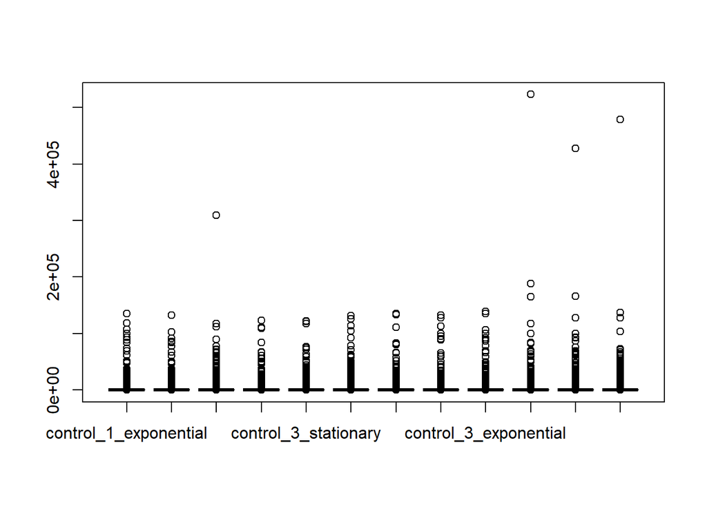

```r
#[1]  9.378066 11.280635

#Researchers did not apply log2:
boxplot(countsM)
```

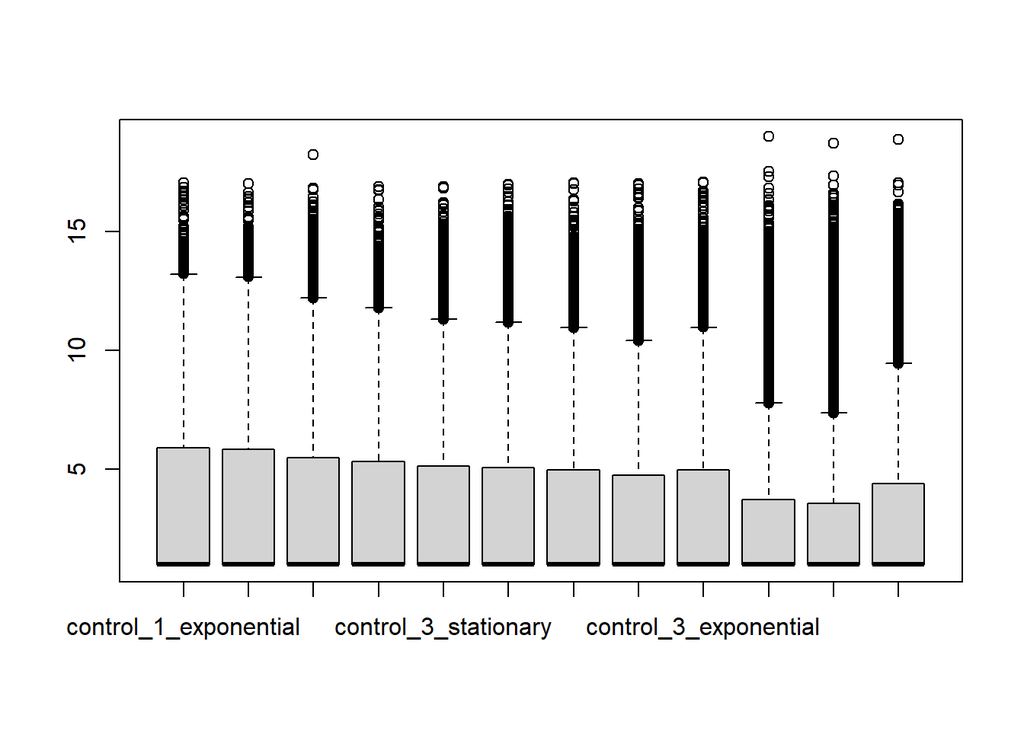

```r
boxplot(log2(countsM+2))
```

```r
#Library size
lSize <- colSums(countsM)
#Again, around 10M each sample suggests homogeneity
lSize
```

```
## control_1_exponential  marine_1_exponential  marine_3_exponential
##              11201653              10854584              10910058
##  marine_2_exponential  control_3_stationary  control_2_stationary
##              10117702               9743950              11280635
##  control_1_stationary   marine_3_stationary control_3_exponential
##              10588014              10271681              10998420
## control_2_exponential   marine_1_stationary   marine_2_stationary
##              10055451              10054987               9378066
```

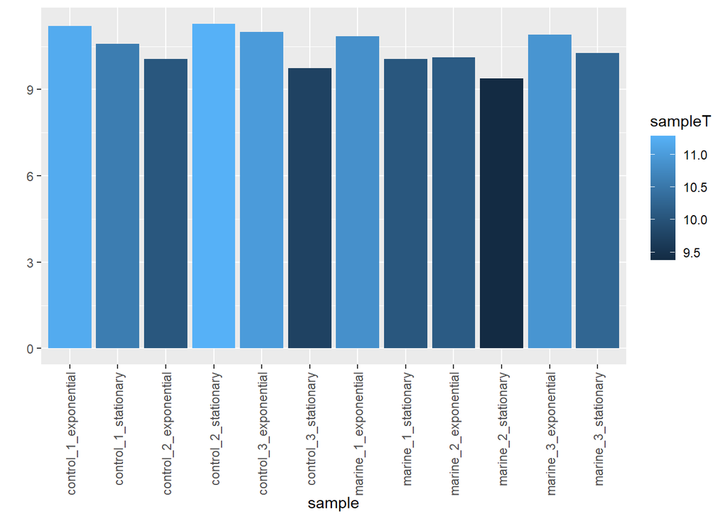

```r
sampleTDF <- data.frame(sample=names(sampleT), total=sampleT)

p <- ggplot(aes(x=sample, y=sampleT, fill=sampleT), data=sampleTDF) + geom_bar(stat="identity")
p + theme(axis.text.x = element_text(angle = 90, vjust = 0.5, hjust=1)) + ylab("")
```

PART 3: Perform quality assessment. Comment results and decide whether they have enough quality to be analysed and remove outlier samples if necessary

```r
#FILTERING
# One of the characteristics of RNA-seq data is that it contains a lot of zeros, corresponding to genes that
# are not expressed. It is therefore important to remove genes that consistently have zero or very low counts.
# In this case we will only keep genes that have at least 10 reads in at least 3 samples.
# One recommendation for the number of samples would be set to the smallest group size.
# In our example, all group of controls and case-treatments have 3 samples.


#Checking dimensions
dim(countsM)
```

```
## [1] 57640    12
```

```r
# 57640
keep <- rowSums(countsM > 10) >= 3# at least 3 samples have 10 reads per gene
countsF <- countsM[keep,]
# Notice the decrease in the number of rows in the counts table after filtering
dim(countsF)
```

```
## [1] 31411    12
```

```r
#31411
#Examining the filtered data:
head(countsF)
```

```
##                       control_1_exponential marine_1_exponential
## TRINITY_DN0_c0_g1                   1734.80              1785.04
## TRINITY_DN0_c0_g2                   2650.98              2830.99
## TRINITY_DN0_c1_g1                   3348.39              3423.11
## TRINITY_DN10001_c0_g1                 25.65                23.45
## TRINITY_DN10004_c0_g1                  9.75                 6.08
## TRINITY_DN10007_c0_g1                  0.00                 0.00
##                       marine_3_exponential marine_2_exponential
## TRINITY_DN0_c0_g1                  1536.36               845.64
## TRINITY_DN0_c0_g2                  1258.69                22.06
## TRINITY_DN0_c1_g1                  4301.40              3276.43
## TRINITY_DN10001_c0_g1                63.93                13.36
## TRINITY_DN10004_c0_g1                 3.16                 8.50
## TRINITY_DN10007_c0_g1                 0.00                28.84
##                       control_3_stationary control_2_stationary
## TRINITY_DN0_c0_g1                   847.33              1046.28
## TRINITY_DN0_c0_g2                   180.94                66.67
## TRINITY_DN0_c1_g1                  5541.85              4695.68
## TRINITY_DN10001_c0_g1                18.03                34.52
## TRINITY_DN10004_c0_g1                10.72                 4.40
## TRINITY_DN10007_c0_g1                12.76                11.17
##                       control_1_stationary marine_3_stationary
## TRINITY_DN0_c0_g1                  1268.97             1315.90
## TRINITY_DN0_c0_g2                  1120.21             1574.24
## TRINITY_DN0_c1_g1                  5004.53             4847.92
## TRINITY_DN10001_c0_g1                79.94               74.57
## TRINITY_DN10004_c0_g1                29.01               10.17
## TRINITY_DN10007_c0_g1                 0.00                0.00
##                       control_3_exponential control_2_exponential
## TRINITY_DN0_c0_g1                   1362.15               1458.24
## TRINITY_DN0_c0_g2                   1397.90                 98.14
## TRINITY_DN0_c1_g1                   5076.09               3898.40
## TRINITY_DN10001_c0_g1                 73.80                 11.97
## TRINITY_DN10004_c0_g1                 12.98                  0.00
## TRINITY_DN10007_c0_g1                  0.00                 12.87
##                       marine_1_stationary marine_2_stationary
## TRINITY_DN0_c0_g1                 1360.04             1258.16
## TRINITY_DN0_c0_g2                   96.03              112.35
## TRINITY_DN0_c1_g1                 3298.74             2823.45
## TRINITY_DN10001_c0_g1               10.46               22.23
## TRINITY_DN10004_c0_g1                0.00                2.91
## TRINITY_DN10007_c0_g1                0.00               13.04
```

PART 4:Normalize data SVCD NORMALIZATION:

```r
#NORMALIZATION

#The following text was borrowed from Dr. Lana Nonnel UVic Transciptomic course webpage:
#https://aules.uvic.cat/pluginfile.php/1578837/mod_resource/content/3/RNAseq.html
# "There are several methods that can be used to normalize values in count matrices.
# Traditionally, CPM (Counts Per Million), RPKM (Reads Per Kilobase Million) or FPKM (Fragments Per Kilobase Million)
# were used to report RNA-seq results. However, TPM (Transcripts Per Kilobase Million) is now more popular.
# CPM divide the counts by library size whereas RPKM/FPKM and TPM scale the data using gene length and library size.
# When comparing samples, TMM (Trimmed Mean on the M-values) is the standard method to report results.
# Other methods include also the GC content in the normalization step."
#Current methods of normalization for RNA-Seq, such as RPKM, TMM, and DESeq, perform between-sample normalization by introducing
#a scaling per sample obtained with some form of mean or median, using all or a large set of genes.
#Thus their performance is expected to be similar to that of Median normalization for microarrays.
#Since the microalgal organism Chlorella sp. HS2 evaluated in the study did not have a reference genome and instead
#had its genome constructed de Novo, its annotation gene information, etc. was not expected to be found in Ensembl
#database or accessed via BiomaRt. Therefore, normalization using RPKM, FPKM or TPM that require the gene length
#was not performed here. Instead SCVD, TMM, and CPM were performed:

#SCVD NORMALIZATION:

# Standard-Vector Condition-Decomposition normalization (SVCD normalization) was used in this algal study and is first demonstrate here:
#For SVCD, the following publication and webpage are referenced:
#Publication: Roca, Gomes, Amorim & Scott-Fordsmand: Variation-preserving normalization unveils blind spots in gene expression profiling.
#Sci. Rep. 7, 42460; doi:10.1038/srep42460 (2017).
#Webpage:https://rdrr.io/github/carlosproca/cdnormbio/man/normalize.svcd.html

# "With the exception of Quantile normalization, all used methods apply a multiplicative factor to the expression levels of each sample,
#equivalent to the addition of a number in the usual log2-scale for gene expression
# levels. Solving the normalization problem consists of finding these correction factors.
# For SVCD normalization, a vectorial procedure carries out each normalization step, called
# Standard-Vector normalization. The samples of any experimental condition, in a properly normalized dataset, must be exchangeable.
#In mathematical terms, the expression levels of each gene can be considered as an
# s-dimensional vector, where s is the number of samples for the experimental condition. After standardization
# (mean subtraction and variance scaling), these standard vectors are located in a (s− 2)-dimensional hypersphere.
# Such exchangeability implies that, when properly normalized, the distribution of standard vectors must be invariant with respect
#to permutations of the samples and must have zero expected value. These properties allow to obtain a robust estimator of the
#normalization factors, under fairly general assumptions that do not imply any particular distribution of gene expression.

#SVCD (Standard-Vector Condition-Decomposition) Normalization normalizes gene expression data following the SVCD algorithm.
#It also provides the estimated normalization factors and the no-variation features (e.g. genes) detected.

#Components are briefly defined as follows:
# expression.data: Numeric matrix with expression data. Rows correspond to features, for example genes.
# Columns correspond to samples. If rows and/or columns do not have names, they are assigned names with format "feature.[number]"
# and/or "sample.[number]", respectively.
#
# expression.condition: character or numeric vector defining the experimental conditions. It can also be a factor.
# The length of expression.condition must be equal to the number of columns of expression.data, that is, to the number of samples.
# It can contain NA values, meaning samples to be ignored in the normalization.
#
# restrict.feature:When restrict.feature is NULL, all features can be used for normalizing. Otherwise, restrict.feature is expected
# to be a character or numeric vector identifying the features, by name or index respectively, that can be used for normalizing.
#
# search.h0.feature:Logical value indicating whether no-variation features should be searched for the final between-condition normalization,
# thus restricting the set of features used in this normalization. When search.h0.feature is FALSE, the complete set of features used
# in the within-condition normalizations is also used for normalizing between conditions.
#
# convergence.threshold: Numeric vector with four elements, defining convergence parameters for the algorithm.
# The format is (single.step, multiple.step, single.step.search.h0.feature, multiple.step.search.h0.feature).
# Using values different from the default ones is only advisable when the implementation of convergence is understood in detail.
#
# stdvec.graph: When not NULL, it provides a character string with the name of a directory to save graphs displaying the convergence
# of standard vectors, grouping conditions in sets of three. The directory can be entered as an absolute or relative path, and it is created
# if it does not exist. To save in the current working directory, use stdvec.graph="." or stdvec.graph="".
# Generating the graphs of standard vectors requires the package plotrix.
#
# p.value.graph:When not NULL, it provides a character string with the name of a directory to save graphs displaying the
# distributions of p-values used for the identification of no-variation features. The directory can be entered as an absolute
# or relative path, and it is created if it does not exist. To save in the current working directory, use p.value.graph="." or p.value.graph="".
#
# verbose:Logical value indicating whether convergence information should be printed to the console.
#
# Offset: Vector of detected normalization factors, with one factor per sample".

#SVCD Normalization without offset is first performed here with following packages installed:
#To install cdnormbio from GitHub repository, using the function install_github in the devtools package:
#install.packages("remotes")
#remotes::install_github("carlosproca/cdnormbio")
library(devtools)
#install_github("carlosproca/cdnormbio", force = TRUE)
library(cdnormbio)

expr.data <- countsF
expr.condition <- c("control_exponential", "marine_exponential","marine_exponential","marine_exponential","control_stationary","control_stationary","control_stationary","marine_stationary", "control_exponential","control_exponential","marine_stationary","marine_stationary")
#The following statements unfortunately generated the error: Error in normalize.standard.vector(edata[norm.feature.idx, ], condition, : normalize.svcd: No convergence:

#normalize.result <- normalize.svcd(expr.data, expr.condition,restrict.feature = NULL,search.h0.feature = TRUE, convergence.threshold = c(0.01, 0.1, 0.01, 1), stdvec.graph = NULL, p.value.graph = NULL, verbose = FALSE)
#sd(normalize.result$offset)
#length(normalize.result$h0.feature)

# The following SVCD Normalization with offset as shown below was also not successfully performed here:
# offset.added <- rnorm(colcount(countsF))
# expr.data <- sweep( expr.data, 2, offset.added, "+" )
# normalize.result <- normalize.svcd(expr.data, expr.condition, stdvec.graph = "svcd_stdvec", p.value.graph = "svcd_p_value", verbose = TRUE )
# sd( normalize.result$offset - offset.added )
# length( normalize.result$h0.feature)

#THEREFORE SVCD NORMALIZATION THAT WAS PERFORMED BY STUDY COULD NOT BE REPLICATED HERE. INSTEAD TMM AND CBM NORMALIZATION WERE PERFORMED:
```